# Innovation and the Future of Science

Erol Taymaz  
http://users.metu.edu.tr/etaymaz

2 November 2018

# The great transformation

- Digital economy
- Industry 4.0
- Post-industrial society
- Knowledge economy
- Knowledge-based economy
- Information society
- New economy
- Network economy
- Techno-capitalism
- Internet economy

# Digital technologies

- Technological basis of the great transformation
  - Digital form for all types of knowledge
  - Technological convergence

# Characteristics of knowledge (production)

- Non-rival
- Non-excludable
- Economies of scale
  - High fixed cost of production / low cost of reproduction
- Network externalities
  - Users’ benefits increase by the number of users

# Open science

Scientific production (knowledge) requires **open science**

- Replication of scientific research
  - Reproducible
- Cumulative learning
  - Further development of science

# Science and innovations

Changing role of “knowledge”

- Knowledge as a factor of production
  - The role of knowledge in increasing productivity
- Knowledge as a product
  - Increasing (scientific) knowledge content of new products

**Innovations draw from (basic) science**

# Changes in the product landscape

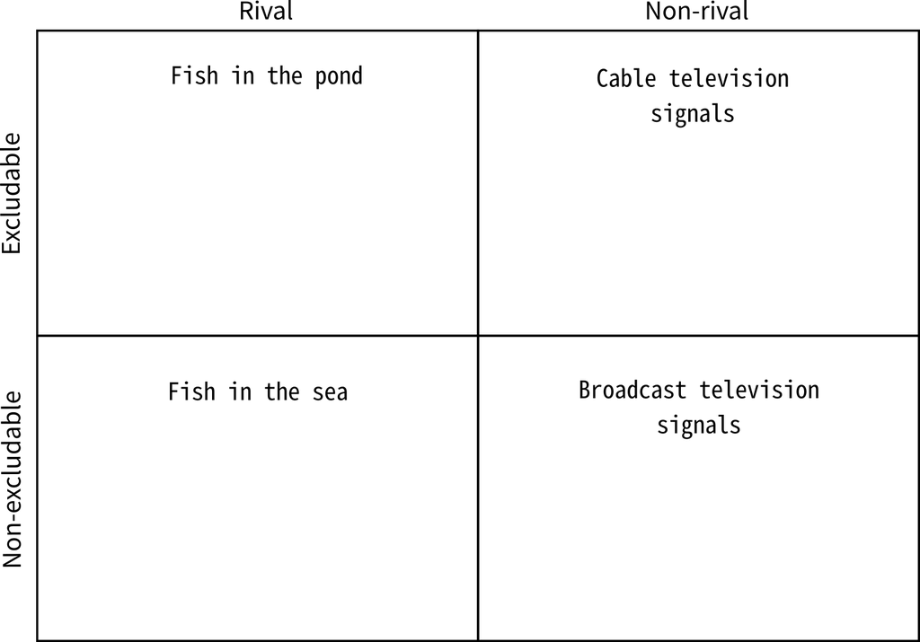

# Changes in the product landscape

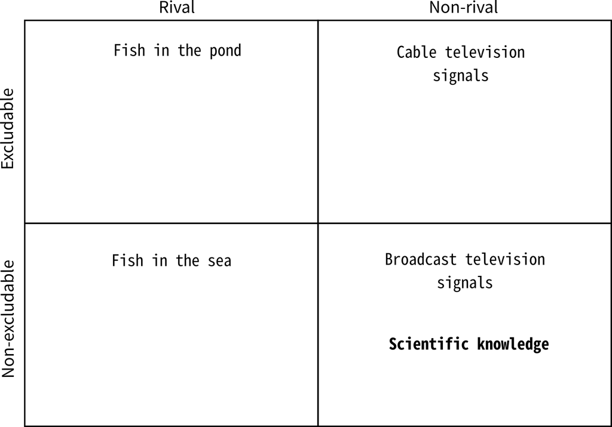

# Implications

- Effective cooperation - community driven innovation
  - Open source - copyleft
  - Open innovation
  - Open science
- Privatization of (basic) science
  - Patents law (wider scope)
  - Copyright / DRM (Digital Rights Management)
    - Digital Restrictions Management
  - University-industry cooperation and university patenting
- Accumulation and centralization of knowledge
- Government, governance and public finance (tax policies)
- Meaning and measurement of “value”

# Open science

**Open science is necessary for**

- scientific development
- innovativeness

**Open innovation is important for**

- innovativeness
- scientific development